# basic_http_requests

```python
import pandas as pd
import matplotlib.pyplot as plt

%matplotlib inline
```

## Web Scraping and Examining Solar Energy Usage:

In this notebook we continue our analysis of Solar energy data collected here:

http://www.energy.ca.gov/almanac/renewables_data/solar/index.php

In the previous notebook we developed a few key functions to process the tables on the energy website. We will reuse those here:

```python
def find_table(name, tables):
    return {t.iloc[0,0]: t for t in tables}[name].copy()
```

```python
def clean_solar_table(table):
    table = table.copy()
    # Extract and set the column names
    table.columns = table.iloc[1,:].values
    # drop headers and summary at end
    table = table.iloc[2:-1]
    # Change types
    table = table.astype({"Year": "int", "Net MWh": "float", "Capacity (MW)": "float"})
    return table.reset_index(drop=True)
```

```python
def extract_and_combine_pv_and_thermal(tables):
    thermal_table = clean_solar_table(find_table("Solar Thermal", tables))
    pv_table = clean_solar_table(find_table("Solar PV", tables))
    thermal_table["Kind"] = "Thermal"
    pv_table["Kind"] = "PV"
    return pd.concat([thermal_table, pv_table]).reset_index(drop=True)
```

# Examining Sources Over Time

What if we wanted to examine these sources overtime? We can get more information from the website:

Try opening the page using developer tools in [Chrome](https://developer.chrome.com/devtools) or [Safari](https://developer.apple.com/safari/tools/).

[figure not shown]

Notice that we can select a different year. To do this we would need to send some additional information to the web server. If you look at the HTML source on the right you see that the website requires `POST`ing additional values to access a particular year.

We can do this using the Python [`requests` library](http://docs.python-requests.org/en/master/user/quickstart/):

In the following we make `POST` request with the body containing `newYear=2012`

```python
import requests
resp = requests.post(
    "http://www.energy.ca.gov/almanac/renewables_data/solar/index.php",
    data = {'newYear':'2012'})
resp
```

```
<Response [200]>
```

### Examining the Request

```python
resp.request.method
```

```
'POST'
```

```python
resp.request.path_url
```

```
'/almanac/renewables_data/solar/index.php'
```

```python
for k in resp.request.headers:
    print(k, "=", resp.request.headers[k])
```

```
User-Agent = python-requests/2.18.4
Accept-Encoding = gzip, deflate
Accept = */*
Connection = keep-alive
Content-Length = 12
Content-Type = application/x-www-form-urlencoded
```

```python
resp.request.body
```

```
'newYear=2012'
```

### Examining the Response

```python
resp.status_code
```

```
200
```

```python
for k in resp.headers:
    print(k, ":", resp.headers[k])
```

```
Date : Tue, 13 Feb 2018 08:42:23 GMT
Server : Apache/2.4.6 (Red Hat Enterprise Linux) PHP/5.4.16
X-Powered-By : PHP/5.4.16
Keep-Alive : timeout=5, max=100
Connection : Keep-Alive
Transfer-Encoding : chunked
Content-Type : text/html; charset=UTF-8
```

```python
resp.content[0:500]
```

```
b'<!DOCTYPE html PUBLIC "-//W3C//DTD XHTML 1.0 Strict//EN" "http://www.w3.org/TR/xhtml1/DTD/xhtml1-strict.dtd" >\r\n<html xmlns="http://www.w3.org/1999/xhtml" xml:lang="en" lang="en" >\r\n<head>\r\n\r\n<title>California Solar Energy Statistics &amp; Data</title>\r\n\r\n<!-- META -->\r\n<meta http-eq…
```

Notice that the content is currently encoded as raw bytes. If we wanted to work on the text version of the content we would need to decode it to the correct string encoding. This can be done using the `decode` function and the type defined in response header.

```python
encoding = resp.headers['Content-Type'].split("=")[-1]
encoding
```

```
'UTF-8'
```

```python
resp.content.decode(encoding)[0:500]
```

```
'<!DOCTYPE html PUBLIC "-//W3C//DTD XHTML 1.0 Strict//EN" "http://www.w3.org/TR/xhtml1/DTD/xhtml1-strict.dtd" >\r\n<html xmlns="http://www.w3.org/1999/xhtml" xml:lang="en" lang="en" >\r\n<head>\r\n\r\n<title>California Solar Energy Statistics &amp; Data</title>\r\n\r\n<!-- META -->\r\n<meta http-equ…
```

## Loading the Response into Pandas

Alternatively, we can send the HTML to Pandas to decode into tables as before. Notice that we have now changed the year.

```python
tables = pd.read_html(resp.content, encoding=encoding)
for t in tables:
    display(t.head())
```

|  | 0 | 1 | 2 | 3 | 4 | 5 | 6 | 7 |
| --- | --- | --- | --- | --- | --- | --- | --- | --- |
| 0 | Solar Thermal | NaN | NaN | NaN | NaN | NaN | NaN | NaN |
| 1 | Year | Company Name | EIA Plant ID | CEC Plant ID | Plant Name | State | Capacity (MW) | Net MWh |
| 2 | 2012 | Sunray Energy Inc | 10437 | S0069 | SEGS I - Retired 12/31/2015 | CA | 13.8 | 14709 |
| 3 | 2012 | Sunray Energy Inc | 10438 | S0070 | SEGS II - Retired 12/31/2015 | CA | 30.0 | 37205 |
| 4 | 2012 | Luz Solar Partners Ltd III | 10439 | S0071 | SEGS III | CA | 34.2 | 70934 |

|  | 0 | 1 | 2 | 3 | 4 | 5 | 6 | 7 |
| --- | --- | --- | --- | --- | --- | --- | --- | --- |
| 0 | Solar PV | NaN | NaN | NaN | NaN | NaN | NaN | NaN |
| 1 | Year | Company Name | EIA Plant ID | CEC Plant ID | Plant Name | State | Capacity (MW) | Net MWh |
| 2 | 2012 | Los Angeles Department of Water & Power (LADWP) | 57305 | S0218 | Adelanto Solar Power Project | CA | 10.0 | 9883 |
| 3 | 2012 | Not Available | Missing | S9149 | Advanced Micro Decives | CA | 3.0 | 4865 |
| 4 | 2012 | Altus Power America Management | 57697 | S0116 | Aerojet I (3.6MW) Solar Plant | CA | 3.6 | 6749 |

|  | 0 | 1 | 2 | 3 | 4 | 5 | 6 | 7 |
| --- | --- | --- | --- | --- | --- | --- | --- | --- |
| 0 | Year | Company Name | EIA Plant ID | CEC Plant ID | Plant Name | State | Capacity (MW) | Net MWh |
| 1 | 2012 | Agua Caliente Solar LLC | 57373 | S0242 | Agua Caliente Solar (AZ) | AZ | 243.0 | 378105 |
| 2 | 2012 | Copper Mountain Solar | 57205 | S0243 | Copper Mountain I (NV) | NV | 58.0 | 65958 |
| 3 | 2012 | Copper Mountain Solar | 58017 | S0244 | Copper Mountain II (NV) | NV | 94.5 | 73593 |
| 4 | NaN | Total | 395.5 | 517656 | NaN | NaN | NaN | NaN |

|  | 0 | 1 | 2 |
| --- | --- | --- | --- |
| 0 | Year | Capacity (MW) | Net MWh |
| 1 | 2016 | 11500.1 | 23080144 |
| 2 | 2015 | 8500.9 | 18061557 |
| 3 | 2014 | 7053.4 | 12732661 |
| 4 | 2013 | 4424.4 | 5500727 |

|  | 0 | 1 | 2 |
| --- | --- | --- | --- |
| 0 | County | Capacity (MW) | Net MWh |
| 1 | Alameda | 14.5 | 23542 |
| 2 | Butte | 5.2 | 7620 |
| 3 | Calaveras | 1.8 | 2838 |
| 4 | Clark | 152.5 | 139551 |

# Downloading All Years

We would now like to programmatically extract the data for all the available years. We can break this into three steps:

1. Get the list of possible years
2. Download the data for each year
3. Combine the data into a single DataFrame

## Get the list of possible years

We would like to programatically extract the possible years we can submit to the form. To do this we will use the [`BeatifulSoup` (version 4) Library](https://www.crummy.com/software/BeautifulSoup/bs4/doc/). This is a fairly sophisticated library for reading and navigating HTML documents. We won't cover this library in detail in Data100 but it will be helpful for you to know about it:

```python
from bs4 import BeautifulSoup
```

### Beautiful Soup Makes HTML Readable

You can use Beautiful soup to parse an HTML document and reindent it:

```python
dom = BeautifulSoup(resp.content.decode(encoding), "html.parser")
print(dom.prettify())
```

[output not shown]

[output cut: 8793 more lines]

[output not shown]

### Finding the list of years

If we return to the web page and explore the DOM we find that the form has an `id`.

[figure not shown]

**Div `id`s are (should be) unique so we can look for this form in the DOM tree by searching for the `id`.**

```python
forms = dom.find_all(id="goYear")
forms
```

```
[<select id="goYear" name="newYear">
 <option value="2016">Go to a Different Year</option><option value="2016">2016</option><option value="2015">2015</option><option value="2014">2014</option><option value="2013">2013</option><option value="2012">2012</option><option value="2011">2011</option><option value="2010">2010</option><option v…
 </select>]
```

```python
print(forms[0].prettify())
```

```
<select id="goYear" name="newYear">
 <option value="2016">
  Go to a Different Year
 </option>
 <option value="2016">
  2016
 </option>
 <option value="2015">
  2015
 </option>
 <option value="2014">
  2014
 </option>
 <option value="2013">
  2013
 </option>
 <option value="2012">
  2012
 </option>
 <option value="2011">
  2011
 </option>
 <option value="2010">
  2010
 </option>
 <option value="2009">
  2009
 </option>
 <option value="2008">
  2008
 </option>
 <option value="2007">
  2007
 </option>
 <option value="2006">
  2006
 </option>
 <option value="2005">
  2005
 </option>
 <option value="2004">
  2004
 </option>
 <option value="2003">
  2003
 </option>
 <option value="2002">
  2002
 </option>
 <option value="2001">
  2001
 </option>
</select>
```

Notice that this form contains several option tags. We can find all the option tags in this form:

```python
form = forms[0]
opt_tags = form.find_all("option")
opt_tags
```

```
[<option value="2016">Go to a Different Year</option>,
 <option value="2016">2016</option>,
 <option value="2015">2015</option>,
 <option value="2014">2014</option>,
 <option value="2013">2013</option>,
 <option value="2012">2012</option>,
 <option value="2011">2011</option>,
 <option value="2010">2010</option>,
 <option value="2009">2009</option>,
 <option value="2008">2008</option>,
 <option value="2007">2007</option>,
 <option value="2006">2006</option>,
 <option value="2005">2005</option>,
 <option value="2004">2004</option>,
 <option value="2003">2003</option>,
 <option value="2002">2002</option>,
 <option value="2001">2001</option>]
```

This again returns a list of elements. Notice that each option has a value attribute that is posted in the form. Let's extract these attributes:

```python
[o.attrs for o in opt_tags]
```

```
[{'value': '2016'},
 {'value': '2016'},
 {'value': '2015'},
 {'value': '2014'},
 {'value': '2013'},
 {'value': '2012'},
 {'value': '2011'},
 {'value': '2010'},
 {'value': '2009'},
 {'value': '2008'},
 {'value': '2007'},
 {'value': '2006'},
 {'value': '2005'},
 {'value': '2004'},
 {'value': '2003'},
 {'value': '2002'},
 {'value': '2001'}]
```

The attributes are python dictionary objects so we can get the year by using the key `"value"`

```python
years = set([o.attrs["value"] for o in opt_tags])
years
```

```
{'2001',
 '2002',
 '2003',
 '2004',
 '2005',
 '2006',
 '2007',
 '2008',
 '2009',
 '2010',
 '2011',
 '2012',
 '2013',
 '2014',
 '2015',
 '2016'}
```

## Download All the Data

In the following block of code we use the years that we just collected to **repeatedly** query the website and download all the data for each year.

```python
dfs = []

for y in years:
    print("Downloading Year:", y)

    # Get the data
    r = requests.post("http://www.energy.ca.gov/almanac/renewables_data/solar/index.php",
              data = {'newYear': y})

    # Get all the tables
    tables = pd.read_html(r.content)

    # Get the two tables
    df = extract_and_combine_pv_and_thermal(tables)

    # Save the dataframe
    dfs.append(df)
```

```
Downloading Year: 2008
Downloading Year: 2010
Downloading Year: 2013
Downloading Year: 2007
Downloading Year: 2002
Downloading Year: 2011
Downloading Year: 2014
Downloading Year: 2003
Downloading Year: 2005
Downloading Year: 2006
Downloading Year: 2001
Downloading Year: 2012
Downloading Year: 2004
Downloading Year: 2009
Downloading Year: 2016
Downloading Year: 2015
```

## Combine All the Data into a single Dataframe

```python
data = pd.concat(dfs).reset_index(drop=True)
```

```python
data.head()
```

|  | Year | Company Name | EIA Plant ID | CEC Plant ID | Plant Name | State | Capacity (MW) | Net MWh | Kind |
| --- | --- | --- | --- | --- | --- | --- | --- | --- | --- |
| 0 | 2008 | Sunray Energy Inc | 10437 | S0069 | SEGS I - Retired 12/31/2015 | CA | 13.8 | 12666.0 | Thermal |
| 1 | 2008 | Sunray Energy Inc | 10438 | S0070 | SEGS II - Retired 12/31/2015 | CA | 30.0 | 30318.0 | Thermal |
| 2 | 2008 | Luz Solar Partners Ltd III | 10439 | S0071 | SEGS III | CA | 34.2 | 72360.0 | Thermal |
| 3 | 2008 | Luz Solar Partners Ltd IV | 10440 | S0072 | SEGS IV | CA | 34.2 | 72516.0 | Thermal |
| 4 | 2008 | Luz Solar Partners Ltd IX | 10446 | S0073 | SEGS IX | CA | 92.0 | 166154.0 | Thermal |

### Save a Backup

```python
data.to_csv("cal_energy_data_all_years.csv")
```

# Finishing the Analysis

Let's examine the growth in the Thermal and PV energy production over the past decade.

1. Construct a Pivot Table of **year** by **kind** with the entries containing the total **Net MWh**.
2. Plot it!

```python
data.pivot_table(values="Net MWh",
                 index="Year", columns="Kind", aggfunc="sum")
```

| Kind Year | PV | Thermal |
| --- | --- | --- |
| 2001 | 2576.0 | 833708.0 |
| 2002 | 2462.0 | 848325.0 |
| 2003 | 1949.0 | 756571.0 |
| 2004 | 1956.0 | 739123.0 |
| 2005 | 1989.0 | 658333.0 |
| 2006 | 2297.0 | 613591.0 |
| 2007 | 2208.0 | 665750.0 |
| 2008 | 3395.0 | 730152.0 |
| 2009 | 16559.0 | 840520.0 |
| 2010 | 89577.0 | 878835.0 |
| 2011 | 225808.0 | 888843.0 |
| 2012 | 1018269.0 | 866941.0 |
| 2013 | 3775231.0 | 685849.0 |
| 2014 | 9100352.0 | 1623568.0 |
| 2015 | 13032887.0 | 2446285.0 |
| 2016 | 17234537.0 | 2548090.0 |

```
Text(0,0.5,'Net MWh')
```

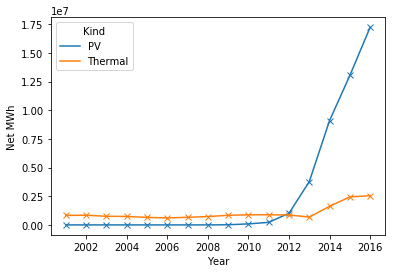

```python
fig = (
    data.pivot_table(values="Net MWh",
                     index="Year", columns="Kind", aggfunc="sum")
        .plot(kind='line')
)
ax = fig.axes
plt.setp(ax.lines, marker="x")
ax.set_ylabel("Net MWh")
```

## Interactive Plotly Visualization

```python
import plotly.offline as py
py.init_notebook_mode(connected=False)

import plotly.graph_objs as go
import plotly.figure_factory as ff
import cufflinks as cf

cf.set_config_file(offline=False, world_readable=True, theme='ggplot')
```

```python
(
    data.pivot_table(values="Net MWh",
                     index="Year", columns="Kind", aggfunc="sum")
        .iplot(kind='line',  yTitle = "Net MWh")
)
```

[interactive chart not shown]

```python
(
    data.pivot_table(values="Capacity (MW)",
                     index="Year", columns="Kind", aggfunc="sum")
        .iplot(kind='line',  yTitle = "Total Capacity (MW)")
)
```

[interactive chart not shown]

Who are the big providers:

```python
(
    data.groupby("Plant Name")[["Capacity (MW)"]].sum()
        .sort_values("Capacity (MW)")
        .tail(30)
        .iplot(kind='bar',  yTitle = "Total Capacity (MW)")
)
```

[interactive chart not shown]

## The big Producers:

1. [Topaz Solar](https://en.wikipedia.org/wiki/Topaz_Solar_Farm) (PV)
2. [Solar Energy Generating Systems](https://en.wikipedia.org/wiki/Solar_Energy_Generating_Systems) (Thermal)
3. [Desert Sunlight](https://en.wikipedia.org/wiki/Desert_Sunlight_Solar_Farm) (PV)